# EB3I n1 2025 scRNAseq - **Differential expression analysis**

### 4.2.2 From biology to statistics

Okay, let us resort on statistics to evaluate our chances to be guess correctly, or our risks to guess wrong.

We have lots of observations :

- 2838 cells within the G1 phase
- 711 cells within the S phase

Statisticians really like to have **a lot of observations** !

Ideally, statisticians never have enough observations, but at least they prefer when they have **more than tests**.

Here, we have a total of 3549 observations and we are testing a single gene.

We live in a statistician’s wet dream !

Now, if we think like a statistician, we can ask ourselves :

- Are our cells supposed to be interacting with each others ?
- Or are they independent from each others ?
- Does the expression in our cells follow a normal distribution ?

All of this is very important, and usually, it requires a discussion.

For the normal distribution, there is an easy check. Let’s draw the expression like we did above.

First, we use the function [`rbind`](https://www.rdocumentation.org/packages/base/versions/3.6.2/topics/cbind) from `base` package. Be careful, the function `rbind` also exists in `DelayedArray`, `data.table`, and `BiocGenerics` packages ! We want to use the “basic” one.

```r
# distribution_Plac8_table_build

## Add column idientifiers in each count dataframes
Plac8G1$phase <- "G1"
Plac8S$phase <- "S"
## Paste the rows beneith each other
Plac8 <- base::rbind(
  ##  variable pointing to G1 counts
  Plac8G1,
  ##  variable pointing to S counts
  Plac8S,
  ## A Boolean, requesting that strings/characters
  ## should not be casted as `logical`. It breaks graphs.
  stringsAsFactors = FALSE

  )
```

Secondly, we use the function [`gghistogram`](https://www.rdocumentation.org/packages/ggpubr/versions/0.6.0/topics/gghistogram) from the package `ggpubr` in order to display relative abundance of gene expression :

```r
# distribution_Plac8_display

ggpubr::gghistogram(
  Plac8,
  x = "Plac8",
  y = '..density..',
  fill = "steelblue",
  bins = 15,
  add_density = TRUE
)
```

**Show plot**

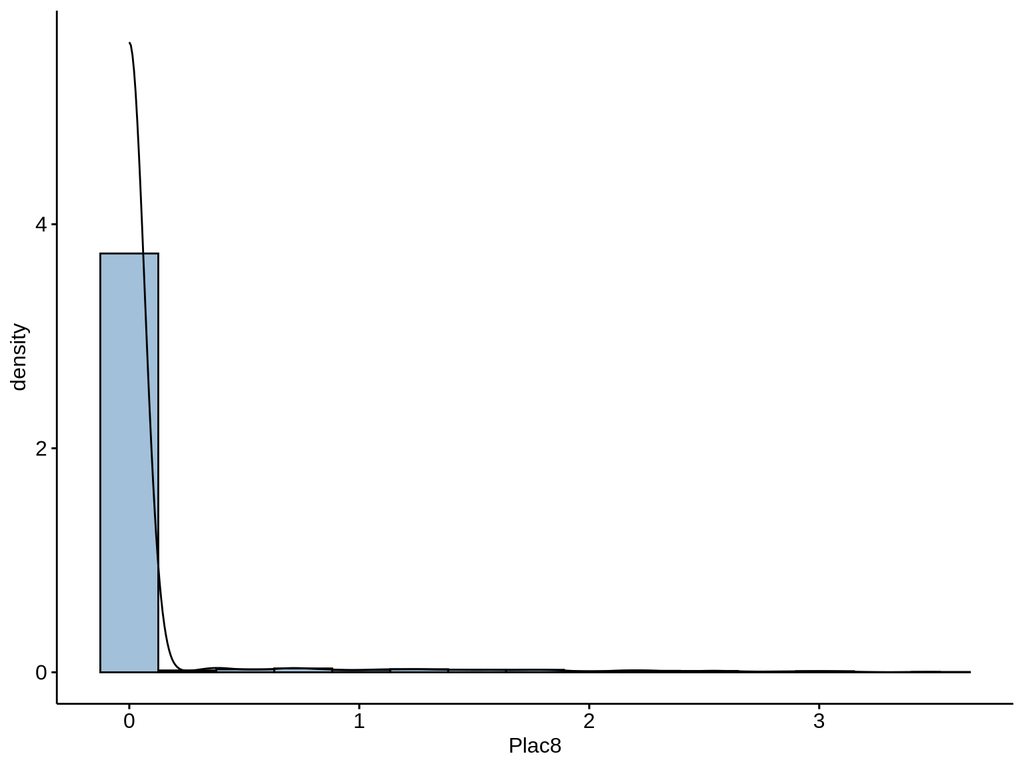

Our distribution doesn’t seem to be normal, nor binomial … we will have to rely on **non-parametric** tests.

Let’s run a non-parametric test based on the mean of distributions, since it’s the clothest to our ‘intuitive’ approach. Let there be [Wilcoxon](https://en.wikipedia.org/wiki/Wilcoxon_signed-rank_test) test.

In R, it’s quite straightforward : we have the function [`wilcoxon_test`](https://www.rdocumentation.org/packages/rstatix/versions/0.7.1) to perform the test, then we can plot the result.

```r
# wilcoxon_Plac8

## On the expression table stored in the varialbe `Plac8`,
## first apply the function `wilcox_test` from package `rstatix`,
## then we apply the function `add_significance` from package `rstatix`
stat.test <- Plac8 %>% rstatix::wilcox_test(Plac8 ~ phase) %>% rstatix::add_significance()

# While doing so, we usually also compute effect size
eff.size <- Plac8 %>% rstatix::wilcox_effsize(Plac8 ~ phase)
```

|  | .y. | group1 | group2 | n1 | n2 | statistic | p | p.signif |
| --- | --- | --- | --- | --- | --- | --- | --- | --- |
| 1 | Plac8 | G1 | S | 2838 | 711 | 841341 | 7.919999999999999e-65 | **** |

We can compute a fold change and conclude.

**NOTE** : Just out of curiosity, be aware that [`t_test`](https://www.rdocumentation.org/packages/rstatix/versions/0.7.2/topics/t_test) from `rstatix` package, gives the same answer (with different significance). However, [`DESeq`](https://satijalab.org/seurat/reference/findmarkers) gives a p-value of 0.05 and an adjusted p-value equal to 1 !

Depending on the test used, this gene is, or is not differentially expressed.

## 4.3 Conclusion

In conclusion, to select your DEA method, use the following rules of thumb :

1. If you have already done a study with one of these methods, keep using the same. This is crutial if you ever want to compare your new result with the old ones.
2. If you want to compare your study with a published one, use the same method.
3. If you have no idea, use Wilcoxon.
4. If you have **bulk** data analyzed with `DESeq2`/`Limma`, use `DESeq2`/`Limma`. It will be easier to take both works in consideration.

**Please, never ever use a simple Wilcoxon on bulk RNA-Seq data !!**

## 4.4 NB MAST DE

MAST uses a hurdle model divided into two parts:

- Discrete – models the probability that a feature is detected in a cell (present or not).
- Continuous – models the level of expression for the feature in cells where it is detected.

MAST also uses the Cellular Detection Rate (CDR) as a covariate to adjust for sequencing effects, calculated as the fraction of detected genes per cell (nFeature barcode >0 / nHVG). It is also possible to include additional covariates, such as batch or experimental metrics, when analyzing more than two samples.

# 5 Select a dataset

## 5.1 Dataset depends on selected method

There it is quite easier:

|  | Counts | slot name |
| --- | --- | --- |
| wilcox | Normalized counts | sojb@assays[['RNA']]@data |
| t_test | Normalized counts | sojb@assays[['RNA']]@data |
| ROC | Normalized counts | sojb@assays[['RNA']]@data |
| ANOVA | Normalized counts | sojb@assays[['RNA']]@data |
| MAST | Raw counts | sojb@assays[['RNA']]@counts |
| DESeq2 | Raw counts | sojb@assays[['RNA']]@counts |
| Limma | Raw counts | sojb@assays[['RNA']]@counts |

## 5.2 FindMarkers

With the function [`FindMarkers`](https://satijalab.org/seurat/reference/findmarkers) from package `Seurat`, we want to make three groups:

1. One using `wilcoxon` to perform DEA between clusters “8” and “10”.
2. One using `t`-test to perform DEA between clusters “8” and “10”.
3. One using `MAST` to perform DEA between “8” and “10”.

We will observe the results and compare our gene lists.

Hey, why are you looking at me? It’s your turn to work! Use the all the notions seen above to select the right counts (`slot`), the right input object, and the right arguments.

10 minutes practice !

**Answers**

Here are the code for each team:

```r
sobj_wilcox <- Seurat::FindMarkers(
  # The variable that contains Seurat Object
  object = sobj,
  # Name of condition 1
  ident.1 = "8",
  # Name of condition 2
  ident.2 = "10",
  # Factor name in the Seurat Object
  group.by = "HarmonyStandalone_clusters",
  # Differential analysis method
  test.use = "wilcox"
)

sobj_t <- Seurat::FindMarkers(
  # The variable that contains Seurat Object
  object = sobj,
  # Name of condition 1
  ident.1 = "8",
  # Name of condition 2
  ident.2 = "10",
  # Factor name in the Seurat Object
  group.by = "HarmonyStandalone_clusters",
  # Differential analysis method
  test.use = "t"
)

sobj_mast <- Seurat::FindMarkers(
  # The variable that contains Seurat Object
  object = sobj,
  # Name of condition 1
  ident.1 = "8",
  # Name of condition 2
  ident.2 = "10",
  # Factor name in the Seurat Object
  group.by = "HarmonyStandalone_clusters",
  # Differential analysis method
  test.use = "MAST"
)
```

In the function argument, there is a FoldChange threshold. Should we filter gene expression based on FoldChange? In case of positive answer, how much should that threshold be?

**Answer**

About thresholds on FDR (False Discovery Rate) and Log2(FC) (Log of the Fold Change), there are many discussions.

Remember, here the threshold on Fold Change is Logged. A `log2(1) =`0. And keep in mind the following:

1. If one selects a fold change threshold above 1.7, then their study concludes that smoking is not related to lung cancer.
2. If one selects a fold change threshold above 1, then their study concludes that a fast-food based diet does not lead to weight gain.
3. If one selects a fold change threshold above 1/25 000 000, then their study concludes: it is a complete hazard that mice have fetal malformation when in presence of Bisphanol.

In conclusion, there one, and only one reason to filter on fold change: in my experience, a fold change below 0.7 will be hard to see/verify on wet-lab (qRT).

If you need to reduce a too large number of differentially expressed genes, then reduce the FDR to 0.01, or even better, to 0.001. With that, you reduce your number of false claims.

Can you help me with `DEseq2`?

When I run the following command line, I have an error :

```r
sobj_deseq2 <- Seurat::FindMarkers(
  # The variable that contains Seurat Object
  object = sobj,
  # Name of condition 1
  ident.1 = 8,
  # Name of condition 2
  ident.2 = 10,
  # Factor name in the Seurat Object
  group.by = "HarmonyStandalone_clusters",
  # Differential analysis method
  test.use = "deseq2",
  # Use non-normalized data with DESeq2
  slot = "counts"
)
```

> Error in PerformDE(object = object, cells.1 = cells.1, cells.2 = cells.2, : Unknown test: deseq2

**Answer**

Oh! My fault, it was a typo in my command! Thank you all for your help!

```r
sobj_deseq2 <- Seurat::FindMarkers(
  # The variable that contains Seurat Object
  object = sobj,
  # Name of condition 1
  ident.1 = "8",
  # Name of condition 2
  ident.2 = "10",
  # Factor name in the Seurat Object
  group.by = "HarmonyStandalone_clusters",
  # Differential analysis method
  test.use = "DESeq2",
  # Use non-normalized data with DESeq2
  slot = "counts"
)
```

# 6 Explore results

## 6.1 Big tables

Let us have a look at the results:

|  | p_val | avg_log2FC | pct.1 | pct.2 | p_val_adj |
| --- | --- | --- | --- | --- | --- |
| Plac8 | 5.424219744126777e-25 | -9.650571358547147 | 0 | 0.98 | 7.011346441258273e-21 |
| Myl10 | 2.303091949033949e-22 | -5.883304343292478 | 0.028 | 0.939 | 2.976976653321282e-18 |
| Gm4632 | 7.485890243045232e-22 | -7.213702831160226 | 0.014 | 0.898 | 9.676261728160267e-18 |
| Cdk6 | 8.105105318243335e-22 | -5.71746113364288 | 0.028 | 0.918 | 1.047665913436134e-17 |
| Crip1 | 1.15069709384265e-20 | -3.859416661306604 | 0.625 | 1 | 1.487391063501009e-16 |
| Rps15a | 1.614361569617082e-20 | -1.837293679521359 | 0.972 | 1 | 2.08672376488704e-16 |
| Cd8b1 | 2.194988841832474e-20 | 5.762471311988804 | 0.972 | 0.102 | 2.837242576952656e-16 |
| Rpl36a | 2.201873284194395e-20 | -2.620661647620564 | 0.653 | 1 | 2.846141407149675e-16 |
| Rps26 | 4.326078368362515e-20 | -1.683588542363119 | 0.958 | 1 | 5.591888898945387e-16 |
| Rpl18 | 4.773612844758657e-20 | -1.408963705704884 | 0.972 | 1 | 6.17037196313504e-16 |

We have the following columns:

1. `p_val`: Ignore this column. Always ignore raw p-values. Look at corrected ones, and if they are missing, then compute them.
2. `avg_log2FC`: Average Log2(FoldChange). Illustrates how much a gene is differentially expressed between samples in each condition.
3. `pct.1`: Percent of cells with gene expression in condition one, here in cluster 8.
4. `pct.2`: Percent of cells with gene expression in condition two, here in cluster 10.
5. `p_val_adj`: The confidence we have in the result. The closer to 0, the lesser is the risk of error.

|  | p_val | avg_log2FC | pct.1 | pct.2 | p_val_adj |
| --- | --- | --- | --- | --- | --- |
| Cd8b1 | 9.274950051923659e-55 | 5.762471311988804 | 0.972 | 0.102 | 1.198880043711652e-50 |
| Cd8a | 2.753121592415855e-49 | 5.134659443465933 | 0.972 | 0.102 | 3.558684970356734e-45 |
| Crip1 | 4.434214979141236e-39 | -3.859416661306604 | 0.625 | 1 | 5.731666282037962e-35 |
| Rps24 | 1.368096879634288e-35 | -1.515201467833674 | 1 | 1 | 1.768402026615281e-31 |
| Cd4 | 1.71882350098327e-33 | 8.970173498555862 | 0.903 | 0 | 2.221751257370974e-29 |
| Rplp0 | 5.344930582205411e-33 | -1.539204498123541 | 1 | 1 | 6.908857270558715e-29 |
| Rps27a | 1.52376971904504e-31 | -1.484660012496067 | 1 | 1 | 1.969624738837619e-27 |
| Rps3a1 | 1.633688988726158e-29 | -1.405725750534748 | 1 | 1 | 2.111706386827431e-25 |
| Rps16 | 1.933644605668619e-28 | -1.234772931952105 | 1 | 1 | 2.499429017287258e-24 |
| Rpl36a | 2.865399414170185e-28 | -2.620661647620564 | 0.653 | 1 | 3.703815282756382e-24 |

We have the following columns:

1. `p_val`: Ignore this column. Always ignore raw p-values. Look at corrected ones, and if they are missing, then compute them.
2. `avg_log2FC`: Average Log2(FoldChange). Illustrates how much a gene is differentially expressed between samples in each condition.
3. `pct.1`: Percent of cells with gene expression in condition one, here in cluster 8.
4. `pct.2`: Percent of cells with gene expression in condition two, here in cluster 10.
5. `p_val_adj`: The confidence we have in the result. The closer to 0, the lesser is the risk of error.

|  | p_val | avg_log2FC | pct.1 | pct.2 | p_val_adj |
| --- | --- | --- | --- | --- | --- |
| Crip1 | 5.747074086067428e-39 | -3.859416661306604 | 0.625 | 1 | 7.428667963650757e-35 |
| Cd8b1 | 8.102186544559096e-36 | 5.762471311988804 | 0.972 | 0.102 | 1.047288632749709e-31 |
| Plac8 | 2.071071380226728e-34 | -9.650571358547147 | 0 | 0.98 | 2.677066866081068e-30 |
| Cd8a | 4.935130136899418e-32 | 5.134659443465933 | 0.972 | 0.102 | 6.379149214956188e-28 |
| Rpl36a | 2.696351081321866e-31 | -2.620661647620564 | 0.653 | 1 | 3.485303407716644e-27 |
| Satb1 | 1.134803782792851e-30 | 2.906934185242793 | 0.958 | 0.776 | 1.466847369638039e-26 |
| Rps15a | 1.393676582363791e-30 | -1.837293679521359 | 0.972 | 1 | 1.801466350363436e-26 |
| Rpsa | 2.181701520190232e-28 | -1.995901190355925 | 0.944 | 1 | 2.820067384997893e-24 |
| Cd4 | 1.011309120656477e-27 | 8.970173498555862 | 0.903 | 0 | 1.307218169360562e-23 |
| Rpl13 | 1.458368061128598e-27 | -1.64035469104847 | 0.958 | 1 | 1.885086555814826e-23 |

We have the following columns:

1. `p_val`: Ignore this column. Always ignore raw p-values. Look at corrected ones, and if they are missing, then compute them.
2. `avg_log2FC`: Average Log2(FoldChange). Illustrates how much a gene is differentially expressed between samples in each condition.
3. `pct.1`: Percent of cells with gene expression in condition one, here in cluster 8.
4. `pct.2`: Percent of cells with gene expression in condition two, here in cluster 10.
5. `p_val_adj`: The confidence we have in the result. The closer to 0, the lesser is the risk of error.

|  | p_val | avg_log2FC | pct.1 | pct.2 | p_val_adj |
| --- | --- | --- | --- | --- | --- |
| Cd8b1 | 9.274950051923659e-55 | 5.762471311988804 | 0.972 | 0.102 | 1.198880043711652e-50 |
| Cd8a | 2.753121592415855e-49 | 5.134659443465933 | 0.972 | 0.102 | 3.558684970356734e-45 |
| Crip1 | 4.434214979141236e-39 | -3.859416661306604 | 0.625 | 1 | 5.731666282037962e-35 |
| Rps24 | 1.368096879634288e-35 | -1.515201467833674 | 1 | 1 | 1.768402026615281e-31 |
| Cd4 | 1.71882350098327e-33 | 8.970173498555862 | 0.903 | 0 | 2.221751257370974e-29 |
| Rplp0 | 5.344930582205411e-33 | -1.539204498123541 | 1 | 1 | 6.908857270558715e-29 |
| Rps27a | 1.52376971904504e-31 | -1.484660012496067 | 1 | 1 | 1.969624738837619e-27 |
| Rps3a1 | 1.633688988726158e-29 | -1.405725750534748 | 1 | 1 | 2.111706386827431e-25 |
| Rps16 | 1.933644605668619e-28 | -1.234772931952105 | 1 | 1 | 2.499429017287258e-24 |
| Rpl36a | 2.865399414170185e-28 | -2.620661647620564 | 0.653 | 1 | 3.703815282756382e-24 |

We have the following columns:

1. `p_val`: Ignore this column. Always ignore raw p-values. Look at corrected ones, and if they are missing, then compute them.
2. `avg_log2FC`: Average Log2(FoldChange). Illustrates how much a gene is differentially expessed between samples in each condition.
3. `pct.1`: Percent of cells with gene expression in condition one, here in cluster 8.
4. `pct.2`: Percent of cells with gene expression in condition two, here in cluster 10.
5. `p_val_adj`: The confidence we have in the result. The closer to 0, the lesser is the risk of error.

## 6.2 Filter DEA results

What kind of threshold should be used to filter each results?

> If we must label certain scores as good or bad, we can reference the following rule of thumb:

> 0.5 = No discrimination 0.5-0.7 = Poor discrimination 0.7-0.8 = Acceptable discrimination 0.8-0.9= Excellent discrimination 0.9 = Outstanding discrimination

Hosmer and Lemeshow in Applied Logistic Regression (p. 177)

## 6.3 Add results to Seurat objects

We’d like to store the results of differential expression analysis in the `Seurat` object.

```r
sobj@misc$wilcox <- sobj_wilcox
```

## 6.4 Common results

Now we can plot intersections in an up-set graph. It is like a Venn diagram:

```r
UpSetR::upset(
  data = UpSetR::fromList(data),
  order.by = "freq"
)
```

**Show plot**

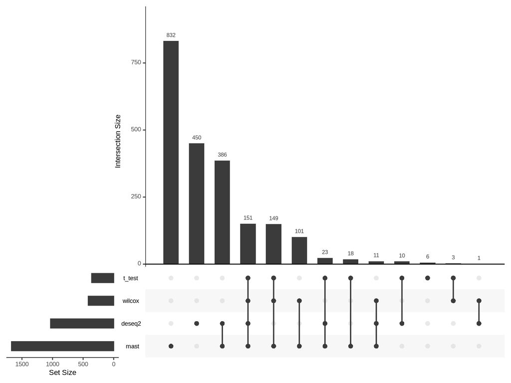

## 6.5 Others functions in Seurat for DEA

There are two other functions in Seurat package to do DEA in different context. For example, you will see the difference between one cluster versus many of them. You could be use `FindAllMarkers`. Usage is equivalent to `FindMarkers` but it need to indicate which variable cluster variable.

```r
sobj_findallmarkers_mast <- FindAllMarkers(sobj,
                                           assay="RNA",
                                           group.by="HarmonyStandalone_clusters",
                                           test.use = "MAST",
                                           only.pos = T,
                                           logfc.threshold = 0.9,
                                           min.pct = 0.1,
                                           random.seed = my_seed)

DT::datatable(
  head(sobj_findallmarkers_mast, n = 10),
  caption = "MAST results"
)
```

|  | p_val | avg_log2FC | pct.1 | pct.2 | p_val_adj | cluster | gene |
| --- | --- | --- | --- | --- | --- | --- | --- |
| Hdgfl3 | 8.303044631395383e-34 | 1.278345077642808 | 0.302 | 0.179 | 1.073251549054167e-29 | 0 | Hdgfl3 |
| Ptcra | 1.336617282044514e-31 | 1.006632305056891 | 0.424 | 0.301 | 1.727711498770739e-27 | 0 | Ptcra |
| Gm525 | 2.120895224370628e-21 | 1.06622314811774 | 0.284 | 0.217 | 2.741469167021474e-17 | 0 | Gm525 |
| Slc5a9 | 1.157889528142643e-20 | 1.696932711587178 | 0.144 | 0.055 | 1.49668800407718e-16 | 0 | Slc5a9 |
| Socs3 | 7.02373337384966e-20 | 1.070756940669398 | 0.289 | 0.177 | 9.07887775903807e-16 | 0 | Socs3 |
| Dnajc13 | 5.269935193083013e-14 | 0.9184077002221714 | 0.112 | 0.092 | 6.811918230579103e-10 | 0 | Dnajc13 |
| Lrig1 | 9.789397873327628e-12 | 1.182793441021964 | 0.128 | 0.07 | 1.265377569106329e-07 | 0 | Lrig1 |
| Rag1 | 1.463874525614491e-88 | 0.9585653956713833 | 0.913 | 0.74 | 1.892204211809291e-84 | 1 | Rag1 |
| Haus3 | 5.668213323426896e-42 | 0.9370280205708198 | 0.287 | 0.262 | 7.326732541861605e-38 | 1 | Haus3 |
| Slc6a19 | 7.655582180479414e-38 | 1.577525316803081 | 0.274 | 0.126 | 9.895605526487691e-34 | 1 | Slc6a19 |

```r
p <- EnhancedVolcano(
  toptable = sobj_findallmarkers_mast,
  lab = rownames(sobj_findallmarkers_mast),
  x = "avg_log2FC",
  y = "p_val_adj",
  FCcutoff = 0.2,
  drawConnectors = FALSE,
  title = 'Volcano by cluster'
)

p + facet_wrap(~ cluster)
```

**Show plot**

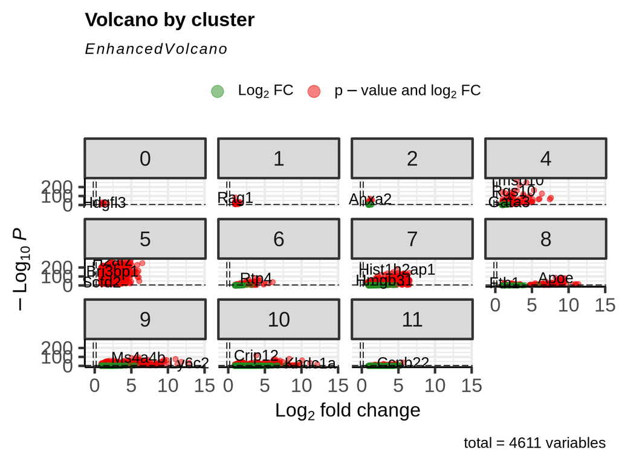

Another function is `FindConservedMarkers`. It the same function of `FindMarkers` but this usage is to identify the same features expression between clusters

```r
sobj_conservedmarkers_mast <- Seurat::FindConservedMarkers(
  # The variable that contains Seurat Object
  object = sobj,
  # Name of condition 1
  ident.1 = "8",
  # Name of condition 2
  ident.2 = "10",
  # Factor name in the Seurat Object
  grouping.var = "orig.ident",
  # Differential analysis method
  assay="RNA",
  slot="counts"
)

DT::datatable(
  head(sobj_conservedmarkers_mast, n = 10),
  caption = "MAST results"
)
```

|  | TDCT_p_val | TDCT_avg_log2FC | TDCT_pct.1 | TDCT_pct.2 | TDCT_p_val_adj | TD3A_p_val | TD3A_avg_log2FC | TD3A_pct.1 | TD3A_pct.2 | TD3A_p_val_adj | max_pval | minimump_p_val |
| --- | --- | --- | --- | --- | --- | --- | --- | --- | --- | --- | --- | --- |
| Plac8 | 3.80319643776075e-05 | -6.332191798320673 | 0 | 0.977 | 0.4916011715449546 | 1.297616829176534e-16 | -9.07677070814879 | 0 | 1 | 1.677299513393588e-12 | 3.80319643776075e-05 | 2.595233658353073e-16 |
| Cd4 | 2.162845780867688e-12 | 9.254872378542629 | 1 | 0 | 2.795694456349574e-08 | 0.0008254832535124836 | 5.6231520851368 | 0.892 | 0 | 1 | 0.0008254832535124836 | 4.325691561730686e-12 |
| Ptrh2 | 0.03562900589987341 | -2.599455104178297 | 0 | 0.432 | 1 | 7.286326019043686e-11 | -4.037090206808339 | 0.015 | 0.8 | 9.418305012215868e-07 | 0.03562900589987341 | 1.457265203755647e-10 |
| Vars | 0.2010703701477772 | -1.386095394346848 | 0 | 0.205 | 1 | 7.286326019043686e-11 | -4.088572594416455 | 0.015 | 0.8 | 9.418305012215868e-07 | 0.2010703701477772 | 1.457265203755647e-10 |
| 2900079G21Rik | 0.3670276039271932 | -0.8448650411468372 | 0 | 0.114 | 1 | 8.800123860482827e-11 | -4.423648024774591 | 0.015 | 0.8 | 1.13750401020601e-06 | 0.3670276039271932 | 1.760024772019123e-10 |
| Cd82 | 0.01908803829705409 | -2.860405176055443 | 0 | 0.5 | 1 | 2.097890993951223e-10 | -3.799590226033749 | 0.062 | 1 | 2.711733898781351e-06 | 0.01908803829705409 | 4.195781987462321e-10 |
| Tcrg-C1 | 0.0003266365794275996 | -5.433174423745411 | 0 | 0.841 | 1 | 2.9066499783028e-10 | -6.403643161689352 | 0 | 0.6 | 3.757135761954199e-06 | 0.0003266365794275996 | 5.813299955760729e-10 |
| Tcrg-C2 | 0.000483471147072643 | -5.432169693254009 | 0 | 0.818 | 1 | 2.9066499783028e-10 | -7.032726142697292 | 0 | 0.6 | 3.757135761954199e-06 | 0.000483471147072643 | 5.813299955760729e-10 |
| Nkg7 | 0.004667148216983322 | -3.997218438733468 | 0 | 0.636 | 1 | 2.9066499783028e-10 | -6.561260714367716 | 0 | 0.6 | 3.757135761954199e-06 | 0.004667148216983322 | 5.813299955760729e-10 |
| Prss57 | 0.004693415287122009 | -3.482921888644044 | 0 | 0.636 | 1 | 2.9066499783028e-10 | -6.267705546565743 | 0 | 0.6 | 3.757135761954199e-06 | 0.004693415287122009 | 5.813299955760729e-10 |

1. `TDCT_p_val`: Ignore this column. Always ignore raw p-values. Look at corrected ones, and if they are missing, then compute them.
2. `TDCT_avg_log2FC`: Average Log2(FoldChange). Illustrates how much a gene is differentially expessed between samples in TDCT condition.
3. `TDCT_pct.1`: Percent of cells with gene expression in condition one, here in cluster 8 in TDCT condition.
4. `TDCT_pct.2`: Percent of cells with gene expression in condition two, here in cluster 10 in TDCT condition.
5. `TDCT_p_val_adj`: The confidence we have in the result. The closer to 0, the lesser is the risk of error in TDCT condition.
6. `TD3A_p_val`: Ignore this column. Always ignore raw p-values. Look at corrected ones, and if they are missing, then compute them.
7. `TD3A_avg_log2FC`: Average Log2(FoldChange). Illustrates how much a gene is differentially expessed between samples in TD3A condition.
8. `TD3A_pct.1`: Percent of cells with gene expression in condition one, here in cluster 8 in TD3A condition.
9. `TD3A_pct.2`: Percent of cells with gene expression in condition two, here in cluster 10 in TD3A condition.
10. `TD3A_p_val_adj`: The confidence we have in the result. The closer to 0, the lesser is the risk of error in TD3A condition.
11. `max_pval`: Maximum of p_val between comparison TDCT vs TD3A. It must be low to indicate a conserved feature
12. `minimump_p_val`: Minimum of p_val between comparison TDCT vs TD3A.

```r
Seurat::VlnPlot(
  # A subset of the Seurat object
  # limited to clusters 8 and 10,
  # or else we will plot all the clusters
  object = subset(sobj, HarmonyStandalone_clusters %in% c("8", "10")),

  # The name of the gene of interest (feature = gene)
  features = "Plac8",

  # The name of the Seurat cell annotation
  split.by = "orig.ident",

  # Change color for presentation
  cols = c("blue", "red")

)
```

[output not shown]